# Lab 2

JP

4/15/2020

# Lab 2

Part A: Multiple Models Run the code below to load the following dataset.

```r
file <- "https://github.com/datalorax/esvis/raw/master/data/benchmarks.rda"
load(url(file))
head(benchmarks)
```

```
##      sid cohort     sped  ethnicity     frl     ell season reading math
## 1 332347      1 Non-Sped Native Am. Non-FRL Non-ELL Winter     208  205
## 2 400047      1 Non-Sped Native Am.     FRL Non-ELL Spring     212  218
## 3 402107      1 Non-Sped      White Non-FRL Non-ELL Winter     201  212
## 4 402547      1 Non-Sped      White Non-FRL Non-ELL   Fall     185  177
## 5 403047      1     Sped   Hispanic     FRL  Active Winter     179  192
## 6 403307      1     Sped   Hispanic Non-FRL Non-ELL Winter     189  188
```

These data are simulated, but represent individual student scores across seasonal benchmark screenings (administered in the fall, winter, and spring). The variables are as follows:

sid: student identifier cohort: student cohort sped: special education status of the student for the given time point ethnicity: coded race/ethnicity of the student frl: free or reduced price lunch eligibility for the student for the given time point ell: English language learner status for the student for the given time point season: season the assessment was administered reading: student’s reading score at the given time point math: student’s mathematics score at the given time point Recode season to wave with the following code

```r
library(tidyverse)
benchmarks <- benchmarks %>%
    as_tibble() %>%
    mutate(wave = case_when(season == "Fall" ~ 0,
                            season == "Winter" ~ 1,
                            TRUE ~ 2))
```

1. Fit a model of the form lm(math ~ wave) for each student.

```r
# names(benchmarks)

by_student <- split(benchmarks, benchmarks$sid)

slopes <- by_student %>%
  map(~lm(math ~ wave, data = .x)) %>%
  map(~coef(.x)) %>%
  map_dbl(2)
```

2. Plot the distribution of slopes. Annotate the plot with a vertical line for the mean.

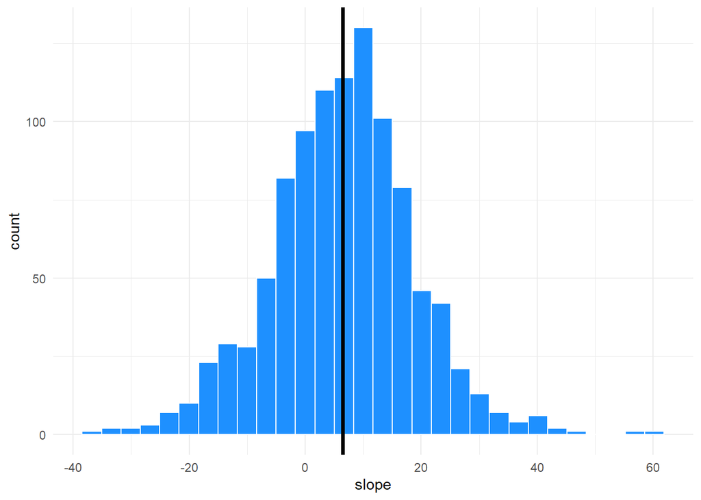

```r
student_plot <- tibble(sid = names(slopes),
                slope = slopes)

student_plot %>%
  ggplot(aes(slope)) +
  geom_histogram(color = 'white', fill = 'dodgerblue') +
  geom_vline(xintercept = mean(slopes, na.rm = TRUE),
             color = 'black',
             size = 1.25) +
  theme_minimal()
```

Part B: Star Wars Install and load the {repurrrsive} package

```r
# install.packages("repurrrsive")
library(repurrrsive)
```

You now should have access to all the data you’ll need for the following.

Use the sw_films list to identify how many characters were represented in each film.

```r
str(sw_films)
```

```
## List of 7
##  $ :List of 14
##   ..$ title        : chr "A New Hope"
##   ..$ episode_id   : int 4
##   ..$ opening_crawl: chr "It is a period of civil war.\r\nRebel spaceships, striking\r\nfrom a hidden base, have won\r\ntheir first victo"| __truncated__
##   ..$ director     : chr "George Lucas"
##   ..$ producer     : chr "Gary Kurtz, Rick McCallum"
##   ..$ release_date : chr "1977-05-25"
##   ..$ characters   : chr [1:18] "http://swapi.co/api/people/1/" "http://swapi.co/api/people/2/" "http://swapi.co/api/people/3/" "http://swapi.co/api/people/4/" ...
##   ..$ planets      : chr [1:3] "http://swapi.co/api/planets/2/" "http://swapi.co/api/planets/3/" "http://swapi.co/api/planets/1/"
##   ..$ starships    : chr [1:8] "http://swapi.co/api/starships/2/" "http://swapi.co/api/starships/3/" "http://swapi.co/api/starships/5/" "http://swapi.co/api/starships/9/" ...
##   ..$ vehicles     : chr [1:4] "http://swapi.co/api/vehicles/4/" "http://swapi.co/api/vehicles/6/" "http://swapi.co/api/vehicles/7/" "http://swapi.co/api/vehicles/8/"
##   ..$ species      : chr [1:5] "http://swapi.co/api/species/5/" "http://swapi.co/api/species/3/" "http://swapi.co/api/species/2/" "http://swapi.co/api/species/1/" ...
##   ..$ created      : chr "2014-12-10T14:23:31.880000Z"
##   ..$ edited       : chr "2015-04-11T09:46:52.774897Z"
##   ..$ url          : chr "http://swapi.co/api/films/1/"
##  $ :List of 14
##   ..$ title        : chr "Attack of the Clones"
##   ..$ episode_id   : int 2
##   ..$ opening_crawl: chr "There is unrest in the Galactic\r\nSenate. Several thousand solar\r\nsystems have declared their\r\nintentions "| __truncated__
##   ..$ director     : chr "George Lucas"
##   ..$ producer     : chr "Rick McCallum"
##   ..$ release_date : chr "2002-05-16"
##   ..$ characters   : chr [1:40] "http://swapi.co/api/people/2/" "http://swapi.co/api/people/3/" "http://swapi.co/api/people/6/" "http://swapi.co/api/people/7/" ...
##   ..$ planets      : chr [1:5] "http://swapi.co/api/planets/8/" "http://swapi.co/api/planets/9/" "http://swapi.co/api/planets/10/" "http://swapi.co/api/planets/11/" ...
##   ..$ starships    : chr [1:9] "http://swapi.co/api/starships/21/" "http://swapi.co/api/starships/39/" "http://swapi.co/api/starships/43/" "http://swapi.co/api/starships/47/" ...
##   ..$ vehicles     : chr [1:11] "http://swapi.co/api/vehicles/4/" "http://swapi.co/api/vehicles/44/" "http://swapi.co/api/vehicles/45/" "http://swapi.co/api/vehicles/46/" ...
##   ..$ species      : chr [1:14] "http://swapi.co/api/species/32/" "http://swapi.co/api/species/33/" "http://swapi.co/api/species/2/" "http://swapi.co/api/species/35/" ...
##   ..$ created      : chr "2014-12-20T10:57:57.886000Z"
##   ..$ edited       : chr "2015-04-11T09:45:01.623982Z"
##   ..$ url          : chr "http://swapi.co/api/films/5/"
##  $ :List of 14
##   ..$ title        : chr "The Phantom Menace"
##   ..$ episode_id   : int 1
##   ..$ opening_crawl: chr "Turmoil has engulfed the\r\nGalactic Republic. The taxation\r\nof trade routes to outlying star\r\nsystems is i"| __truncated__
##   ..$ director     : chr "George Lucas"
##   ..$ producer     : chr "Rick McCallum"
##   ..$ release_date : chr "1999-05-19"
##   ..$ characters   : chr [1:34] "http://swapi.co/api/people/2/" "http://swapi.co/api/people/3/" "http://swapi.co/api/people/10/" "http://swapi.co/api/people/11/" ...
##   ..$ planets      : chr [1:3] "http://swapi.co/api/planets/8/" "http://swapi.co/api/planets/9/" "http://swapi.co/api/planets/1/"
```

[output cut: 50 more lines]

```
##   ..$ url          : chr "http://swapi.co/api/films/2/"
##  $ :List of 13
##   ..$ title        : chr "The Force Awakens"
##   ..$ episode_id   : int 7
##   ..$ opening_crawl: chr "Luke Skywalker has vanished.\r\nIn his absence, the sinister\r\nFIRST ORDER has risen from\r\nthe ashes of the "| __truncated__
##   ..$ director     : chr "J. J. Abrams"
##   ..$ producer     : chr "Kathleen Kennedy, J. J. Abrams, Bryan Burk"
##   ..$ release_date : chr "2015-12-11"
##   ..$ characters   : chr [1:11] "http://swapi.co/api/people/1/" "http://swapi.co/api/people/3/" "http://swapi.co/api/people/5/" "http://swapi.co/api/people/13/" ...
##   ..$ planets      : chr "http://swapi.co/api/planets/61/"
##   ..$ starships    : chr [1:2] "http://swapi.co/api/starships/77/" "http://swapi.co/api/starships/10/"
##   ..$ species      : chr [1:3] "http://swapi.co/api/species/3/" "http://swapi.co/api/species/2/" "http://swapi.co/api/species/1/"
##   ..$ created      : chr "2015-04-17T06:51:30.504780Z"
##   ..$ edited       : chr "2015-12-17T14:31:47.617768Z"
##   ..$ url          : chr "http://swapi.co/api/films/7/"
```

```r
num_characters <- map(sw_films, 'characters') %>%
  map_dbl(length)

num_characters
```

```
## [1] 18 40 34 34 20 16 11
```

Use the sw_species list to (a) identify species that have known hair colors and (b) identify what those hair colors are.

```r
# str(sw_species)

map(sw_species, 'hair_colors')
```

```
## [[1]]
## [1] "n/a"
##
## [[2]]
## [1] "brown, white"
##
## [[3]]
## [1] "none"
##
## [[4]]
## [1] "none"
##
## [[5]]
## [1] "white, brown, black"
##
## [[6]]
## [1] "none"
##
## [[7]]
## [1] "none"
##
## [[8]]
## [1] "none"
##
## [[9]]
## [1] "none"
##
## [[10]]
## [1] "none"
##
## [[11]]
## [1] "none"
##
## [[12]]
## [1] "none"
##
## [[13]]
## [1] "none"
##
## [[14]]
```

[output cut: 55 more lines]

```
##
## [[33]]
## [1] "none"
##
## [[34]]
## [1] "black, brown"
##
## [[35]]
## [1] "n/a"
##
## [[36]]
## [1] "blonde, brown, black, red"
##
## [[37]]
## [1] "n/a"
```

```r
map(sw_species, 'name')
```

```
## [[1]]
## [1] "Hutt"
##
## [[2]]
## [1] "Yoda's species"
##
## [[3]]
## [1] "Trandoshan"
##
## [[4]]
## [1] "Mon Calamari"
##
## [[5]]
## [1] "Ewok"
##
## [[6]]
## [1] "Sullustan"
##
## [[7]]
## [1] "Neimodian"
##
## [[8]]
## [1] "Gungan"
##
## [[9]]
## [1] "Toydarian"
##
## [[10]]
## [1] "Dug"
##
## [[11]]
## [1] "Twi'lek"
##
## [[12]]
## [1] "Aleena"
##
## [[13]]
## [1] "Vulptereen"
##
## [[14]]
```

[output cut: 55 more lines]

```
##
## [[33]]
## [1] "Pau'an"
##
## [[34]]
## [1] "Wookiee"
##
## [[35]]
## [1] "Droid"
##
## [[36]]
## [1] "Human"
##
## [[37]]
## [1] "Rodian"
```

```r
hair_type <- tibble(species_hair = map_chr(sw_species, 'hair_colors'),
                    species_names = map_chr(sw_species, 'name'))

hair_type
```

```
## # A tibble: 37 x 2
##    species_hair        species_names
##    <chr>               <chr>
##  1 n/a                 Hutt
##  2 brown, white        Yoda's species
##  3 none                Trandoshan
##  4 none                Mon Calamari
##  5 white, brown, black Ewok
##  6 none                Sullustan
##  7 none                Neimodian
##  8 none                Gungan
##  9 none                Toydarian
## 10 none                Dug
## # ... with 27 more rows
```

```r
# gt package
# install.packages('gt')
# library(gt)
```

Part C: Some basic API calls Many of the list elements have urls for API calls. For example

```r
sw_films[[1]]$characters[1]
```

```
## [1] "http://swapi.co/api/people/1/"
```

The above provides the url necessary to make an API call for all the information available on the first character in the first film. Unfortunately, this API has since been deprecated. However, we’re going to use essentially equivalent API calls to instead obtain data about pokemon, via https://pokeapi.co/. Feel free to visit the website and look around.

API’s are a way to host databases on the web, and make the data accessible via API calls. We’re going to look at abilities of pokemon. For example to obtain data on the first ability, we could run the following

```r
library(httr)
ability1 <- GET("https://pokeapi.co/api/v2/ability/1") %>%
    content("parsed")

# str(ability1)

ability1$name
```

```
## [1] "stench"
```

```r
length(ability1$pokemon)
```

```
## [1] 7
```

The last digit in “https://pokeapi.co/api/v2/ability/1” is just an index denoting that this is the first ability listed in the database. To obtain data on the third ability, we would instead change our call to “https://pokeapi.co/api/v2/ability/3”.

If you look at the parsed content (it comes in as JSON data) you will see it is a nested list, just like we worked with above for Star Wars.

We can identify what the specific ability is for ability 1 with

ability1$name ## [1] “stench” and the number of pokemon with this ability with

length(ability1$pokemon) ## [1] 7 Use {purrr} to write an API call to obtain data on the first five abilities (note, we’re only using the first five to make the calls go fast, but the code would be essentially equivalent for any number of abilities you wanted to query). Make sure you parse the JSON data to a list.

```r
# create a vector to have all abilities together
api_calls <- paste0('https://pokeapi.co/api/v2/ability/', 1:5)

api_ability <- map(api_calls, ~GET(.x) %>%
      content('parsed'))

ability_name <- map_chr(api_ability, 'name')

ability_name
```

```
## [1] "stench"       "drizzle"      "speed-boost"  "battle-armor" "sturdy"
```

```r
ability_poke <- map(api_ability, 'pokemon') %>%
  map_dbl(length)

ability_poke
```

```
## [1]  7  3 12  9 42
```

Use the parsed data to create a data frame that has the given ability, and the number of pokemon with that ability.

```r
poke_frame <- tibble(ability_name,ability_poke)

poke_frame
```

```
## # A tibble: 5 x 2
##   ability_name ability_poke
##   <chr>               <dbl>
## 1 stench                  7
## 2 drizzle                 3
## 3 speed-boost            12
## 4 battle-armor            9
## 5 sturdy                 42
```

Bonus: Up to 1 point extra credit Create a new data frame that lists the names of the pokemon with these specific abilities. Hint: Try to get the name for one pokemon first, then extend out the logic to get all pokemon names. Also, this is really freaking hard so don’t spend too much time on it and don’t worry if you can’t figure it out.

```r
# str(api_ability)

ability1$pokemon[[1]]$pokemon$name
```

```
## [1] "gloom"
```